# Final Capstone Presentation

Ryan McMurray, Melanie Jensen, Lucca

# Introduction

## The Problem

County assessors face a fundamental data problem: property values are only observed at sale, but must be estimated continuously for taxation.

- Property values are only captured at the point of sale
- Between sales, assessors must estimate value manually — no data-driven basis
- Estimates are inconsistently applied and difficult to defend in court
- The result: property tax assessments that are arbitrary and legally vulnerable

## Data Science Life Cycle

- Data acquisition and representativeness
- Data management
- Data preparation and integration
- Data analysis
- Model development and deployment
- Visualization and communication of the knowledge obtained from the data

# Data Acquisition, Management, and Integration

## Data Consolidation & Segmenting

- **Multi-Source Integration**: Stacked separate Residential, Multi-Family, and Land Sales exports into a unified master frame.
- **Variable Subsetting**: Filtered for high-value modeling features including Parcel ID, Net Price, Date, and physical metrics (GLA, Beds, Baths).
- **Segment Isolation**: Tagged each record by asset class to allow for segment-specific regression analysis.

## Technical Harmonization

- **Identifier Standardization**: Cleaned Parcel and List numbers by stripping non-numeric characters and leading zeros to ensure reliable joining.
- **Math-Ready Validation**: Enforced positive values for prices to prevent errors during Log transformations.
- **Concession Sanitization**: Neutralized missing or null concession data to protect net price calculations.
- **Feature Engineering**: Generated net adjusted sales prices by subtracting seller concessions from gross totals.

## Spatial & Attribute Integration

- **PUMA Data Enrichment**: Merged external spatial attributes using a fallback imputation strategy to maximize data density.
- **Neighborhood Mapping**: Linked properties to specific local Neighborhood Codes (NbhdCode) to capture geographic value drivers.
- **Data Continuity**: Integrated disparate physical features from secondary sources to backfill missing primary record attributes.

## Quality Control & Temporal Integrity

- **Temporal Filtering**: Strictly removed records with missing sales dates to ensure the validity of time-trend piecewise regressions.
- **Bracket Classification**: Created price-tier bins to allow for stratified analysis of market behavior across value levels.
- **Observation Scrubbing**: Dropped records missing core physical descriptors that serve as primary model predictors.

```
Total Adjusted Sales Loaded: 13227
Segments available: ['Residential' 'Land Sales' 'Multi-Family']
```

## Price Adjustment Visual

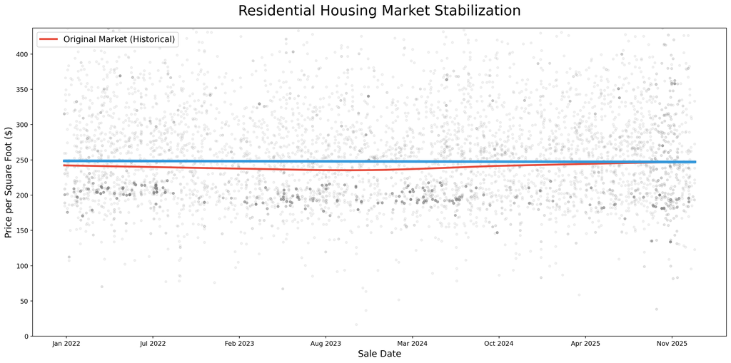

# Data Analysis

## Purposes of Exploratory Analysis

- **Validation of Structural Drivers**: Confirming that physical characteristics (SqFt, Year Built) drive value independent of market volatility.
- **Identification of Feature Interactions**: Real estate value is rarely additive; EDA reveals how variables “handshake” (e.g., Basement Finish value relative to Total GLA).
- **Normalization & Transformation**: Identifying the need for Log-Scale Transformations to ensure “Vertical Equity”—treating a 5% error on a starter home with the same statistical weight as a 5% error on a luxury estate.

## Scree Components

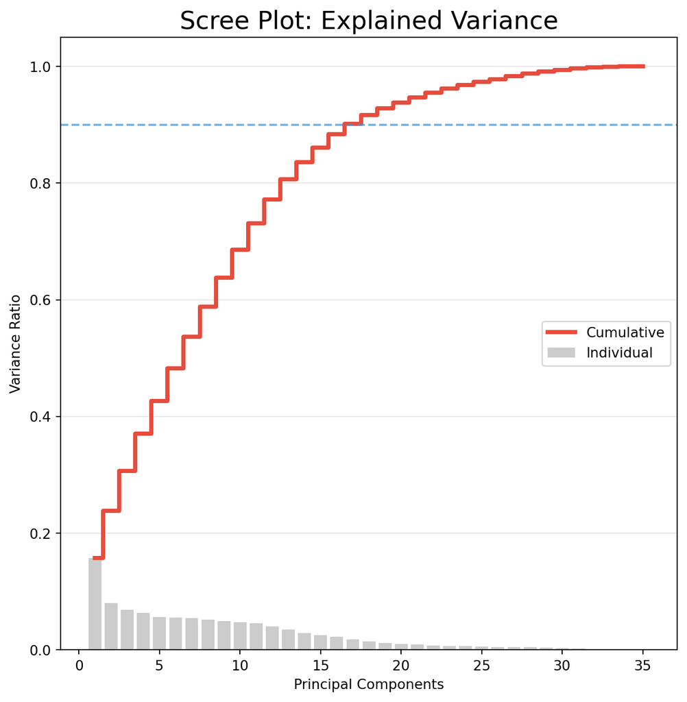

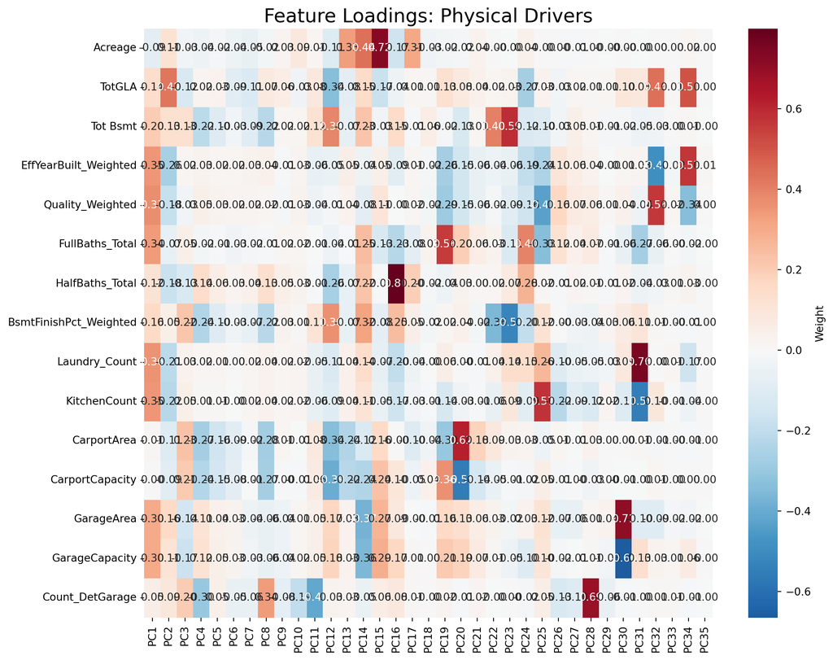

## Residential UMAP

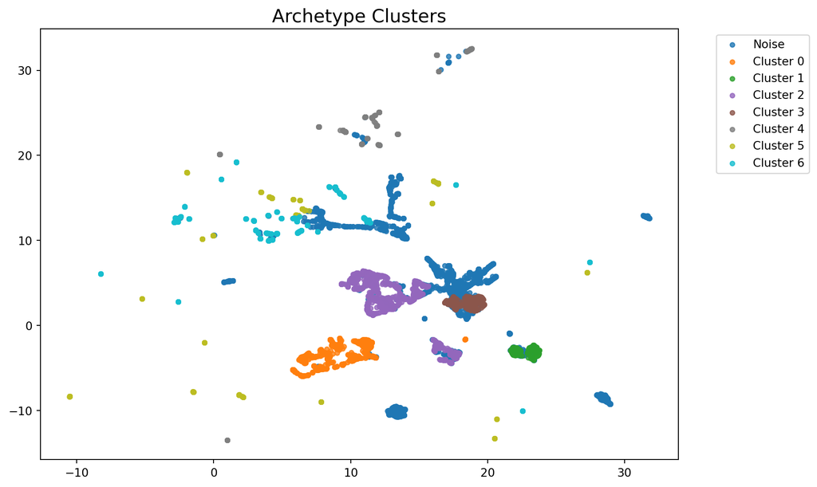

Homes grouped by physical similarity

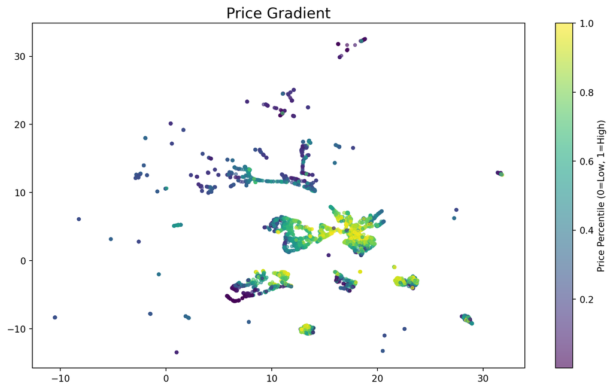

The color gradient reveals the ‘Value Manifold’

# Linear Model

## Linear Model Preperation

Starting Shape:

```
Shape: 13,227 rows × 31 columns
```

Segment breakdown:

```
segment
Residential     6579
Land Sales      6579
Multi-Family      69
```

Post One-Hot-Encoding Shape:

```
Shape: 13,227 rows × 101 columns
```

Drop Outliers:

```
Dropped 760 influence outliers (5.75% of data)
```

Data Split 80/20:

```
Train: 9,973   Test: 2,494
```

## Linear Modeling

```
v4 feature matrix: 117 features (base 101 + 16 engineered)
Lasso tuned α     : 0.00010
Features selected : 87 / 117
Train R²          : 0.8581
Test  R²          : 0.8431
Train–Test gap    : +0.0150
Approx $ MAE      : $40,293
```

```
                            OLS Regression Results
==============================================================================
Dep. Variable:       ln_Trended_Price   R-squared:                       0.858
Model:                            OLS   Adj. R-squared:                  0.857
Method:                 Least Squares   F-statistic:                     720.2
Date:                Sun, 19 Apr 2026   Prob (F-statistic):               0.00
Time:                        20:30:21   Log-Likelihood:                 6545.5
No. Observations:                9973   AIC:                        -1.292e+04
Df Residuals:                    9889   BIC:                        -1.232e+04
Df Model:                          83
Covariance Type:            nonrobust
===========================================================================================================================================
                                                                              coef    std err          t      P>|t|      [0.025      0.975]
-------------------------------------------------------------------------------------------------------------------------------------------
const                                                                       0.5954      0.340      1.753      0.080      -0.071       1.261
EffYearBuilt_Weighted                                                   -8.961e-05   2.41e-05     -3.711      0.000      -0.000   -4.23e-05
Quality_Weighted                                                           -0.1472      0.026     -5.752      0.000      -0.197      -0.097
FullBaths_Total                                                            -0.0069      0.004     -1.962      0.050      -0.014   -7.05e-06
HalfBaths_Total                                                             0.0029      0.004      0.713      0.476      -0.005       0.011
Laundry_Count                                                               0.0145      0.012      1.230      0.219      -0.009       0.038
KitchenCount                                                               -0.0156      0.010     -1.628      0.104      -0.034       0.003
CarportCapacity                                                            -0.0132      0.008     -1.658      0.097      -0.029       0.002
GarageCapacity                                                              0.0184      0.002     10.464      0.000       0.015       0.022
ln_GLA                                                                      2.5103      0.095     26.460      0.000       2.324       2.696
AsinH_Acreage                                                               0.0655      0.007     10.062      0.000       0.053       0.078
AsinH_Land_Value                                                           -0.0032      0.001     -2.273      0.023      -0.006      -0.000
AsinH_Total_Value                                                           0.0990      0.004     23.308      0.000       0.091       0.107
AsinH_Tot_Bsmt                                                              0.0083      0.001     11.347      0.000       0.007       0.010
AsinH_BsmtFin_Pct_Wghted                                                    0.0752      0.008      9.363      0.000       0.059       0.091
AsinH_Carport_Area                                                          0.0034      0.001      2.562      0.010       0.001       0.006
AsinH_SqFt_Det_Garage                                                       0.0035      0.001      4.441      0.000       0.002       0.005
AsinH_SqFt_Det_Carport                                                      0.0013      0.002      0.707      0.480      -0.002       0.005
AsinH_SqFt_Barn                                                             0.0094      0.004      2.195      0.028       0.001       0.018
AsinH_SqFt_Pools                                                            0.0153      0.007      2.229      0.026       0.002       0.029
AsinH_SqFt_Recreational_Courts                                              0.0015      0.006      0.272      0.786      -0.009       0.012
AsinH_SqFt_Shed                                                            -0.0037      0.001     -4.500      0.000      -0.005      -0.002
AsinH_SqFt_Gazebo_Pavilion                                                 -0.0067      0.003     -2.139      0.032      -0.013      -0.001
PropTypeDescription_Comm with Res Exemption                                 0.1582      0.047      3.355      0.001       0.066       0.251
PropTypeDescription_Commercial                                             -0.0048      0.076     -0.063      0.950      -0.153       0.144
PropTypeDescription_DEFAULT                                                 0.4748      0.089      5.312      0.000       0.300       0.650
```

[output cut: 58 more lines]

```
AsinH_Acreage_sq                                                           -0.0116      0.001     -9.297      0.000      -0.014      -0.009
segment_Multi-Family_x_Quality_Weighted                                     0.0294      0.019      1.583      0.113      -0.007       0.066
segment_Multi-Family_x_AsinH_Land_Value                                    -0.0039      0.003     -1.154      0.248      -0.010       0.003
segment_Residential_x_Quality_Weighted                                     -0.0007      0.002     -0.301      0.763      -0.005       0.004
==============================================================================
Omnibus:                      536.789   Durbin-Watson:                   1.999
Prob(Omnibus):                  0.000   Jarque-Bera (JB):             1613.716
Skew:                          -0.244   Prob(JB):                         0.00
Kurtosis:                       4.909   Cond. No.                     1.06e+16
==============================================================================

Notes:
[1] Standard Errors assume that the covariance matrix of the errors is correctly specified.
[2] The smallest eigenvalue is 3.2e-22. This might indicate that there are
strong multicollinearity problems or that the design matrix is singular.
```

## Linear model assumptions

All four assumptions matter more for *inference* (interpreting coefficients, reporting p-values) than for *prediction accuracy*. A model can violate homoscedasticity and still produce useful predictions — the stated uncertainty bounds just can’t be trusted without a robust-standard-error refit.

## Linear Diagnostic Plots

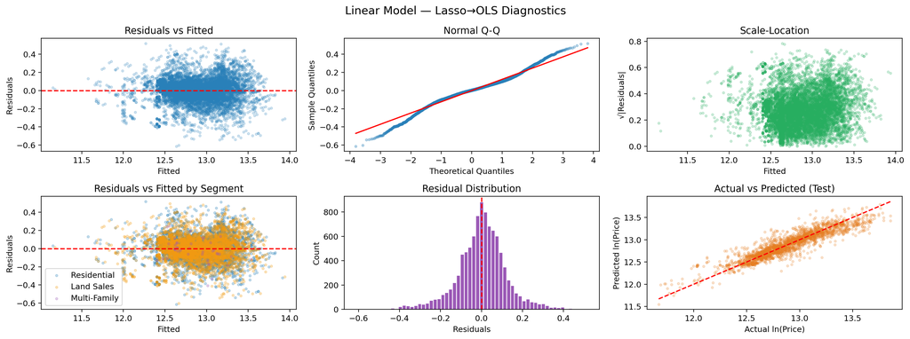

```
Durbin-Watson        : 1.999
Breusch-Pagan p      : 1.48e-209
Residual skew / kurt : -0.244 / 1.911
```

# Light GBM

## Non-Linear Modeling

Starting Shape:

```
Shape: 13,227 rows × 101 cols
```

Drop Outliers:

```
Dropped 727 outliers  (5.50%)
```

Data Split 80/20:

```
Train 10,000   Test 2,500
```

Model Output:

```
LightGBM
  Train R²        : 0.9806
  Test  R²        : 0.9465
  Train–Test gap  : +0.0341
  Test log-MAE    : 0.0490
  Approx $ MAE    : $20,748
```

## Nonlinear model assumptions

LightGBM is a gradient-boosted tree model, and trees assume far less than linear regression. OLS assumptions **do not apply** to tree models. Splits are threshold-based and scale-invariant, so log transforms, polynomial terms, and engineered interactions are unnecessary. The tree discovers all of that from the data. What LightGBM *does* depend on:

1. **i.i.d. train / test data** — same distribution, no drift.
2. **No extrapolation** — trees can’t extend trends past the training range.
3. **Adequate data per region** — sparse segments give noisier predictions and wider intervals.
4. **Stable feature definitions at inference time.**

Because the classical assumptions don’t apply, the diagnostic plots are **descriptive rather than assumption tests**. They check the things that actually matter for a tree model: prediction bias, over/under-fitting, missed non-linear patterns, and calibration for price levels and segments.

## Non-Linear Diagnostic Plots

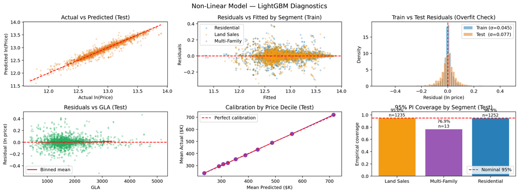

## Bee-Swarm Plot

```
SHAP matrix: (2500, 101)   base value E[ln price] = 12.8621  ≈ $385,433
```

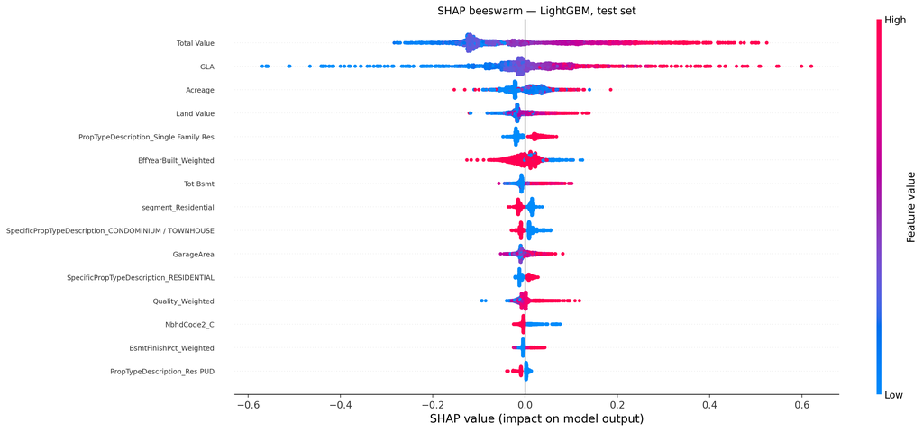

## Waterfall Plot: Median Home

```
  Median residential     predicted $   373,364   actual $   368,823
```

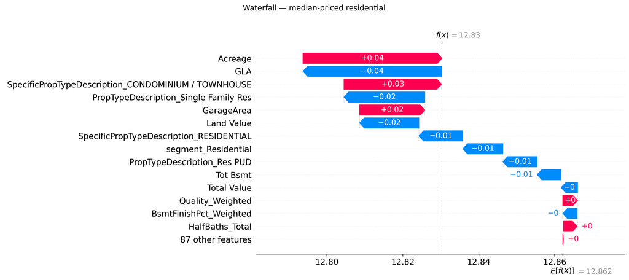

| Feature | Value | Median |
| --- | --- | --- |
| Acreage | 0.12 | 0.17 |
| GLA | 1,428.00 | 1,531.00 |
| SpecificPropTypeDescription_CONDOMINIUM / TOWNHOUSE | 0 | 0.00 |
| PropTypeDescription_Single Family Res | 0 | 0.00 |
| GarageArea | 472.00 | 400.00 |
| Land Value | 15,000.00 | 43,362.00 |
| SpecificPropTypeDescription_RESIDENTIAL | 0 | 0.00 |
| segment_Residential | 1 | 0.00 |
| PropTypeDescription_Res PUD | 1 | 0.00 |
| Tot Bsmt | 0.00 | 0.00 |

## Waterfall Plot: Luxury Home

```
  Luxury residential     predicted $   727,945   actual $ 1,042,858
```

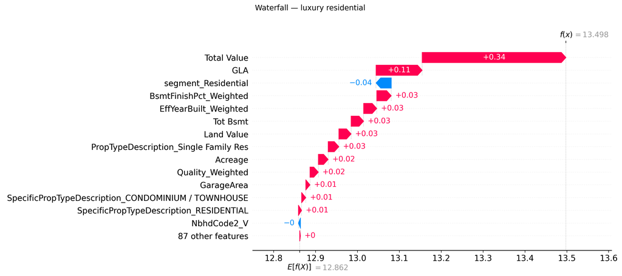

| Feature | Value | Median |
| --- | --- | --- |
| Total Value | 753,409.00 | 322,153.50 |
| GLA | 2,441.00 | 1,531.00 |
| segment_Residential | 1 | 0.00 |
| BsmtFinishPct_Weighted | 1.00 | 0.00 |
| EffYearBuilt_Weighted | 2,021.00 | 2,018.00 |
| Tot Bsmt | 1,756.00 | 0.00 |
| Land Value | 144,246.00 | 43,362.00 |
| PropTypeDescription_Single Family Res | 1 | 0.00 |
| Acreage | 0.51 | 0.17 |
| Quality_Weighted | 4.00 | 3.50 |

## Comparison

```
                      R² (Train) R² (Test) MAE (Test, ln) MAE (Test, $)
Linear (Lasso→OLS)        0.8581    0.8431         0.0933       $40,293
Non-Linear (LightGBM)     0.9806    0.9465         0.0490       $20,748
```

# Concluding Thoughts

## New Tools we Learned to Use

- hdbscan
- lightgbm
- random forest
- SHAP library